# Bayesian mixed models with brms | session 2

Last updated: 2021-04-21

## Outline

- Last session
- Evaluating the posterior
- What are priors?
- Models of keystroke data
- Model comparisons
- Mixture model evaluation
- Summary and recommended reading
- Bonus: Bayes factor

## Last session

## Fit models on simulated data

```r
data <- jens_data_machine(intercept = 300, slope = 15)
```

```r
fit_brm <- brm(y ~ 1 + condition + (1|participant_id), data = data)
```

```r
fixef(fit_brm)
```

```
           Estimate Est.Error   Q2.5  Q97.5
Intercept    300.17      5.99 288.88 311.79
conditionb    15.76      8.05  -0.10  31.46
```

## Model convergence

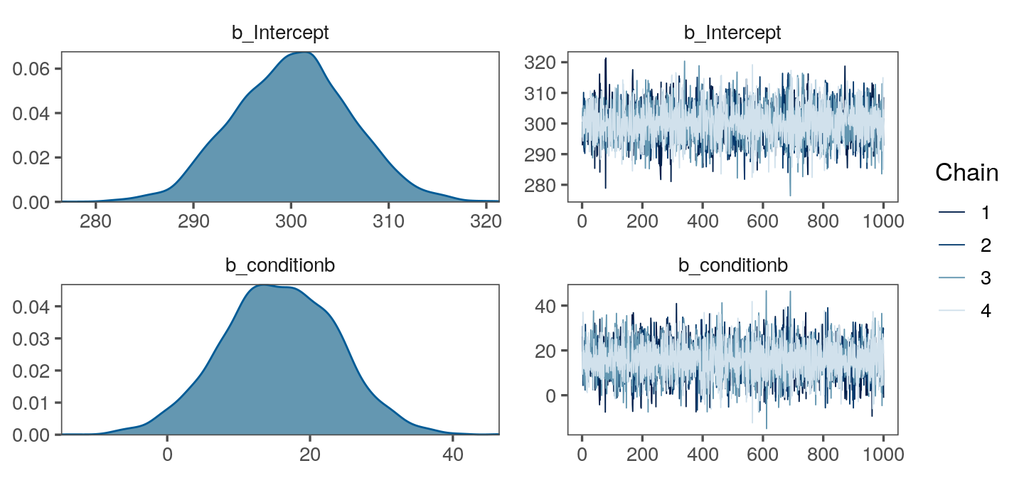

```r
plot(fit_brm, pars = c("b_Intercept", "b_conditionb"))
```

## Model convergence

\(\hat{R}\) convergence statistic; should be \(<1.1\) (Gelman & Rubin, 1992)

```r
rhat(fit_brm, pars = c("b_Intercept", "b_conditionb")) %>% round(3)
```

```
 b_Intercept b_conditionb
       0.999        0.999
```

## Posterior predictive checks

Compare observed data \(y\) and model predictions \(y_{rep}\)

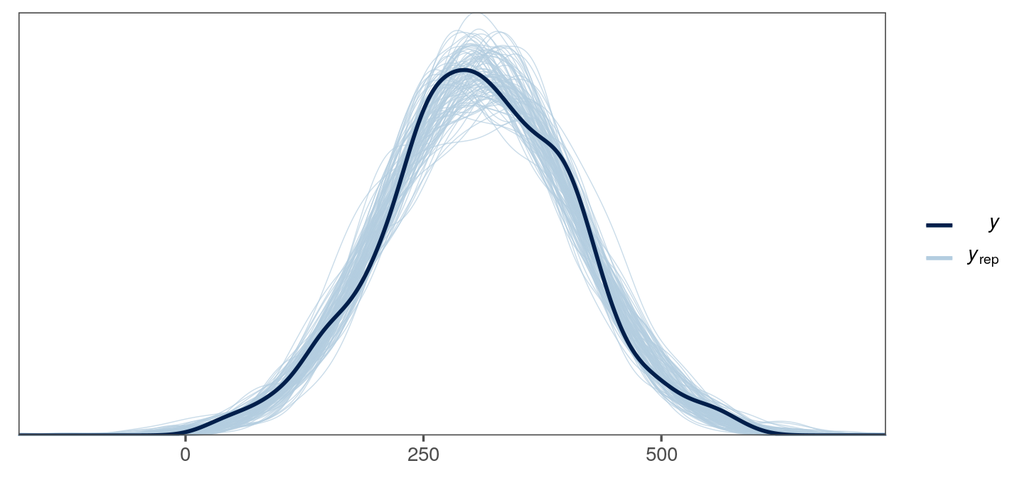

```r
pp_check(fit_brm, nsamples = 100)
```

## Evaluating the posterior

### see e.g. Nicenboim & Vasishth (2016) for a tutorial

## Evaluating the posterior effect \(\beta\)

- Bayesian inference is based on the **posterior**: the result of combining data, probability model, and prior information.
- Estimating true parameter value \(\beta\) (slope; difference between conditions).

```r
beta <- posterior_samples(fit_brm, pars = "b_conditionb") %>% pull()
```

```r
length(beta) # 4 chains with 2000 iterations / 2 (for warmup)
```

```
[1] 4000
```

```r
beta[1:5]
```

```
[1] 26.169134 20.234850  9.773276 21.438894 12.943398
```

## Evaluating the posterior effect \(\beta\)

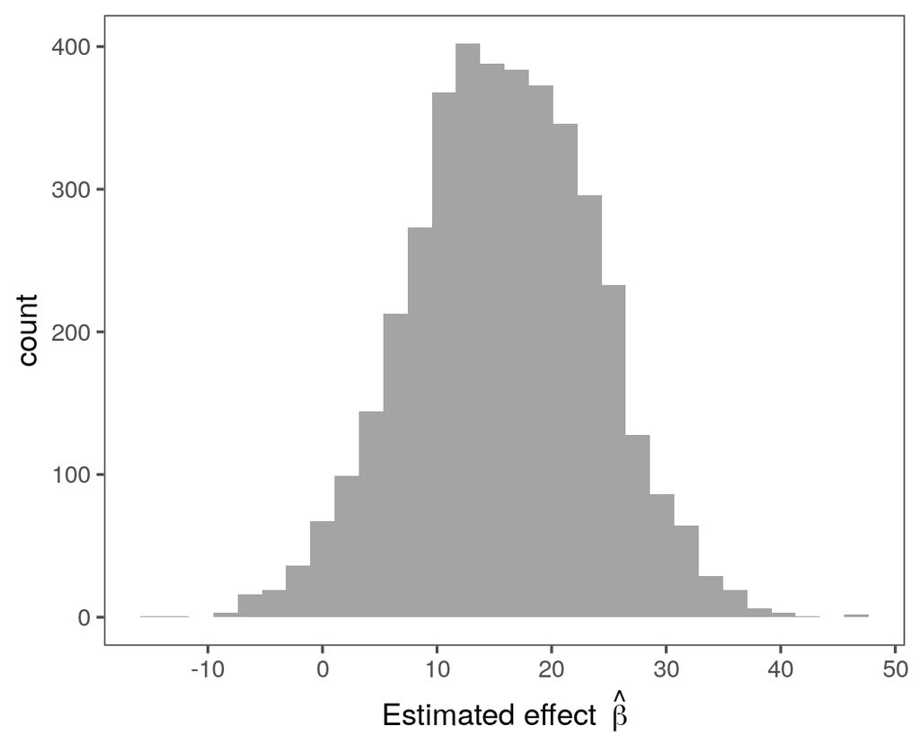

## Evaluating the posterior effect \(\beta\)

- Posterior mean \(\hat\beta\)

```r
mean(beta)
```

```
[1] 15.76034
```

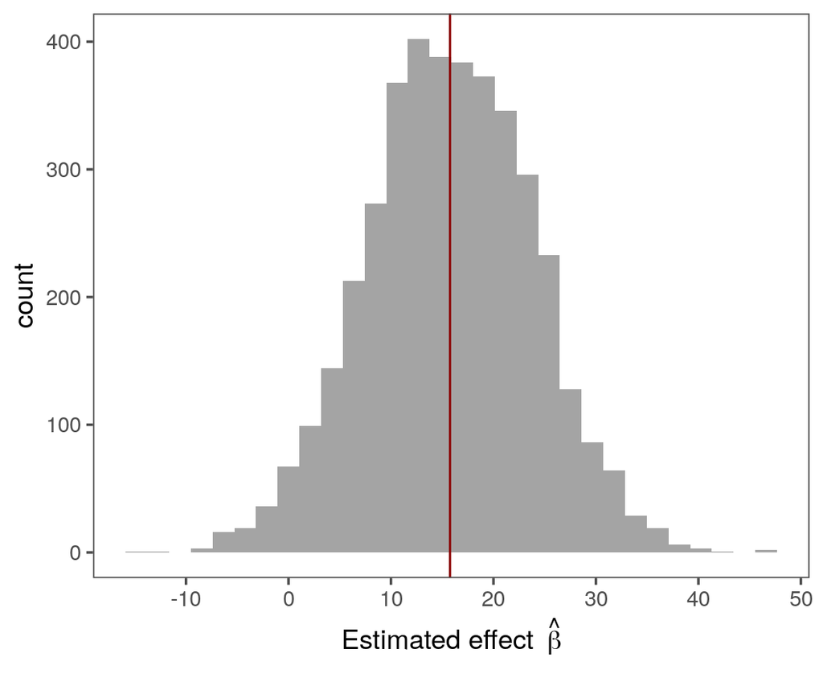

## Evaluating the posterior effect \(\beta\)

- 95% probability interval

```r
quantile(beta, probs = c(0.025, 0.975))
```

```
      2.5%      97.5%
-0.0991772 31.4614818
```

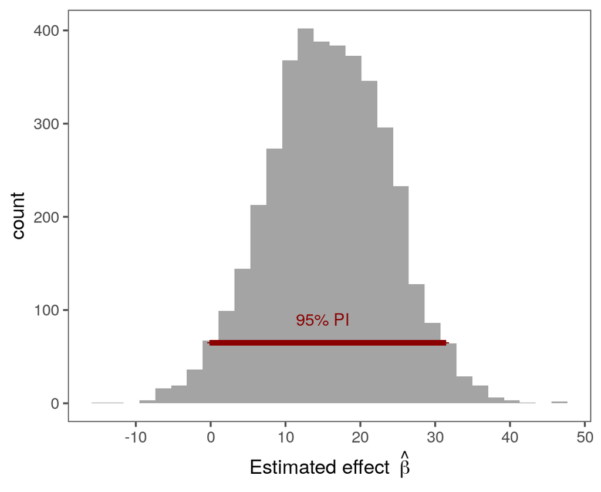

## Evaluating the posterior effect \(\beta\)

- Probability that slope \(\hat\beta\) is negative: \(P(\hat{\beta}<0)\)

```r
mean(beta < 0)
```

```
[1] 0.02775
```

- More in the exercises: `parameter_evaluation.R`
- Formal hypothesis test: `bayes_factors.html` slides (on github)

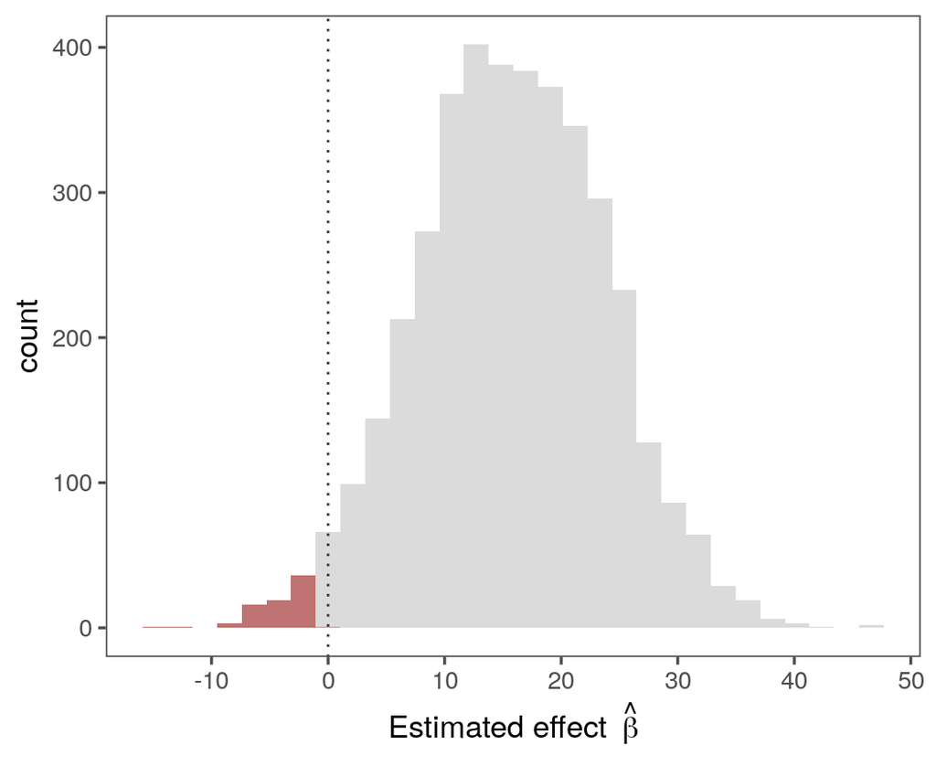

## What are priors?

### chapter 7 in Lee & Wagenmakers (2014)

## Priors

- Prior knowledge about plausible parameter values.
- This knowledge is expressed as probability distributions (e.g. normal distributions).
- Small data will not easily overcome our priors but large data will (automatic Ockham’s razor).
- By default, each parameter value is equally possible (flat priors).
- Even **weakly informative** priors are helpful for estimating parameter values.
- Very specific priors can influence the posterior.

## Priors: intercept

- Intercepts are some form of average.
- Can keystroke intervals range between -\(\infty\) and \(\infty\)?
- How long is the average pause before a sentence?
- Plausible probability distribution for pre-sentence pauses:

## Priors: intercept

- Intercepts are some form of average.
- Can keystroke intervals range between -\(\infty\) and \(\infty\)?
- How long is the average pause before a sentence?
- Plausible probability distribution for pre-sentence pauses:

\[ \text{pre-sentence pause} \sim N(1000 \text{ msecs}, 500\text{ msecs}) \]

## Priors: slope

- We often don’t know what the effect could be.
- However, we have an intuition about what’s plausible and what isn’t.
- If we are not sure, we can use a mean of 0 msecs.

## Priors: slope

- We often don’t know what the effect could be.
- However, we have an intuition about what’s plausible and what isn’t.
- If we are not sure, we can use a mean of 0 msecs.

\[ \text{slope} \sim N(0 \text{ msecs}, 250\text{ msecs}) \]

## Priors

> Check defaults used earlier using `prior_summary()``:

```r
fit_brm <- readRDS(file = "../stanout/brms_sim.rda")
prior_summary(fit_brm)
```

| prior | class | coef | group |
| --- | --- | --- | --- |
| (flat) | b |  |  |
| (flat) | b | conditionb |  |
| student_t(3, 308.2, 98.7) | Intercept |  |  |
| student_t(3, 0, 98.7) | sd |  |  |
| student_t(3, 0, 98.7) | sd |  | participant_id |
| student_t(3, 0, 98.7) | sd | Intercept | participant_id |
| student_t(3, 0, 98.7) | sigma |  |  |

## Student *t*-distribution

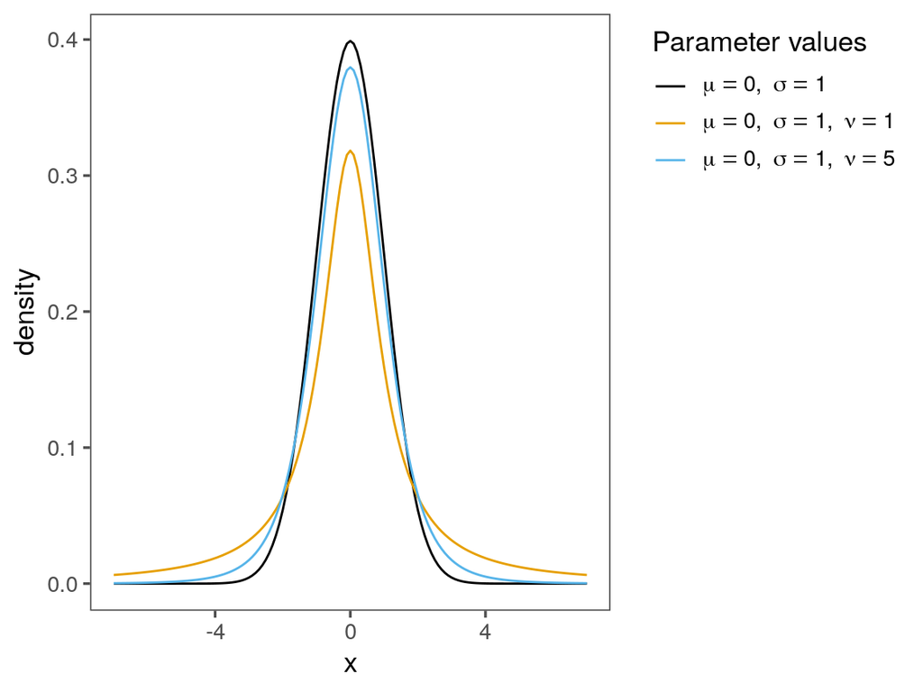

## Prior specification: model

> Instead of

```r
fit <- brm(outcome ~ predictor + (1|participant), data = data)
```

> do …

```r
model <- bf(outcome ~ predictor + (1|participant))

fit <- brm(model, data = data)
```

## Prior specification: prior

```r
model <- bf(outcome ~ predictor + (1|participant))

get_prior(model, data = data)

prior <- set_prior("normal(1000, 500)", class = "Intercept", lb = 0, ub = 100000) +
         set_prior("normal(0, 100)", class = "b") # for slope(s)

fit <- brm(model, data = data, prior = prior)
```

- Adding priors to last session’s model `brms_sim_with_prior.R`.
- Replace the `---`s according to the comments in the script.

## Models of keystroke data

## Models of keystroke data

> “Models are devices that connect theories to data. A model is an instantiation of a theory […]” (Rouder et al., 2016, p. 2)
- Models describe how we understand reality.
- Model allows us to describe reality qualitatively (with their parameters) and quantitatively (parameter value estimates):
- e.g. mean keystroke intervals (to the extent that means are a good summary of keystroke intervals)
- At minimum, distribution families (probability models) depend on data type.
- This isn’t all; there are many distribution families for modeling continuous data.

## Distribution families (some important ones)

- **Gaussian**: data come from normal distribution (last session)

```r
model <- bf(outcome ~ predictor + (1|participant), family = gaussian())
```

## Distribution families (some important ones)

- **Gaussian**: data come from normal distribution (last session)
- **Bernoulli**: binomial outcomes (yes / no; correct / incorrect)

```r
model <- bf(outcome ~ predictor + (1|participant), family = bernoulli())
```

## Distribution families (some important ones)

- **Gaussian**: data come from normal distribution (last session)
- **Bernoulli**: binomial outcomes (yes / no; correct / incorrect)
- **Poisson**: count data (number of words / mistakes)

```r
model <- bf(outcome ~ predictor + (1|participant), family = poisson())
```

## Distribution families (some important ones)

- **Gaussian**: data come from normal distribution (last session)
- **Bernoulli**: binomial outcomes (yes / no; correct / incorrect)
- **Poisson**: count data (number of words / mistakes)
- Families for ordinal (ordered) data (Bürkner & Vuorre, 2019) (Likert scales)

```r
model <- bf(outcome ~ predictor + (1|participant), family = cumulative())# or acat, sratio
```

## Models of keystroke data

- Keystroke data from 39 ppts writing texts.
- Sentence transitions (keystroke interval between sentences).
- Keystroke interval data are heavily skewed.
- Skew is normal and contains important information: additional cognitive demands.

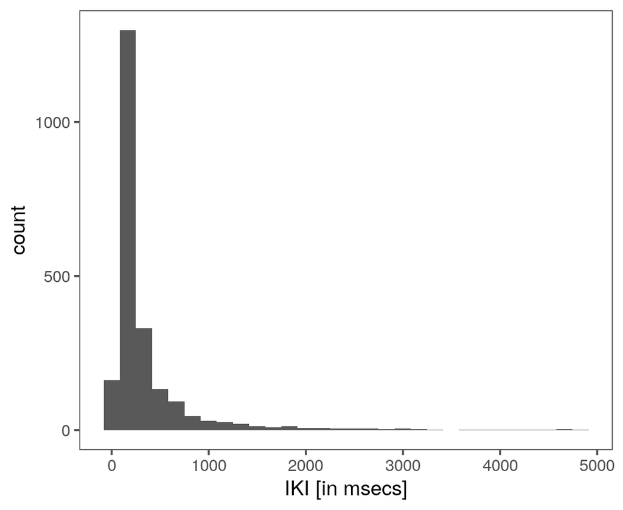

## Models of keystroke data

- A good model of keystroke data should be able to capture the positive skew.
- Many probability models that deal with skew explicitly (see Matzke & Wagenmakers, 2009).
- Describing the data generating process in different ways: entail different ways of thinking about what skew means.
- Homework models:
- Modelling interkeystroke intervals (IKI) after accounting for random variability across participants:
- `IKI ~ 1 + (1|participant)`
- 5 models of keystroke data: Gaussian, log-Normal, skewed-Normal, ex-Gaussian, mixture of log-Normals

## Gaussian

\[y \sim N(\mu, \sigma^2)\]

- Values are symmetrically distributed with a mean \(\mu\) and standard deviation \(\sigma^2\).
- \(\mu\): mean keystroke intervals
- \(\sigma^2\): standard deviation; symmetrical variability around \(\mu\)
- The underlying process that generates data has an equal chance of being slower or faster than the mean.

## Gaussian

```r
model <- bf(IKI ~ 1 + (1|SubNo),
            family = gaussian())
gaussian <- brm(mode, data = data)
```

- Model estimate

```r
round(fixef(gaussian)[,-2])
```

```
Estimate     Q2.5    Q97.5
     380      308      455
```

- Observed mean

```r
round(mean(data$IKI))
```

```
[1] 362
```

## Gaussian

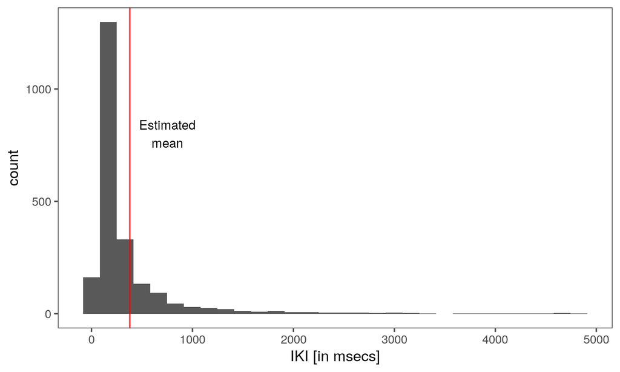

## Log-Normal

- Often used to address positive skew; e.g. response times (Baayen, 2008)
- De-emphasize large values over small values: Difference of 40 msecs can be huge for fast typing but negligible for pauses around 10 secs.
- Log is only defined if \(y \in [0, \infty]\)

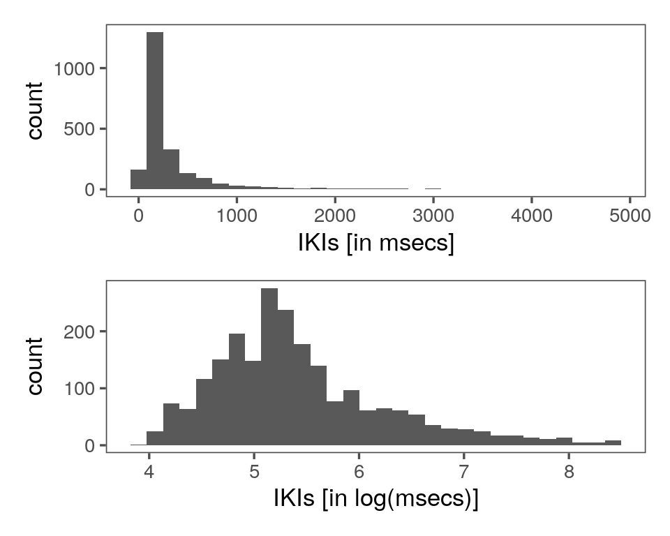

## Log-Normal

```r
model <- bf(IKI ~ 1 + (1|SubNo), family = lognormal())
lognormal <- brm(mode, data = data)
```

- Model estimates

```r
round(exp(fixef(lognormal)[,-2]))
```

```
Estimate     Q2.5    Q97.5
     233      197      275
```

- Observed mean

```r
round(mean(data$IKI))
```

```
[1] 362
```

## Log-Normal

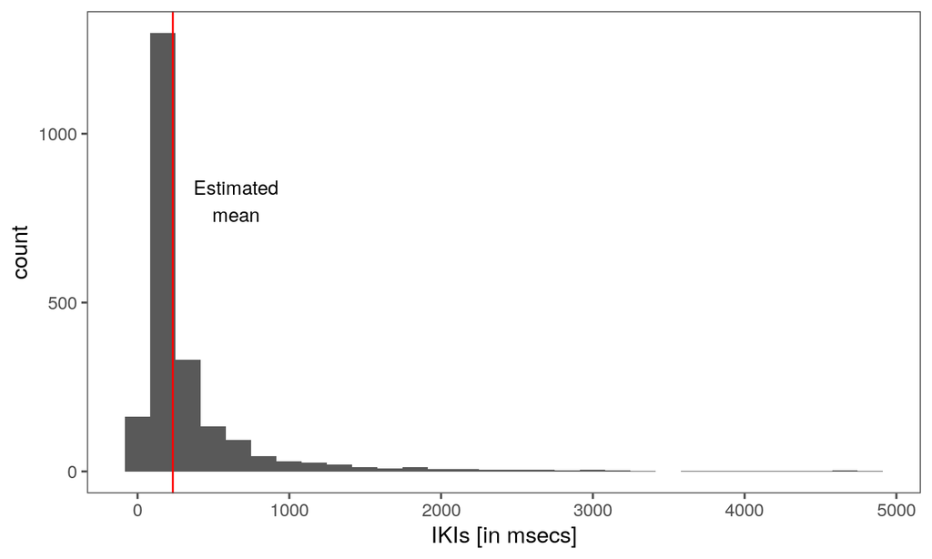

## Ex-Gaussian

- Response is caused by a mix of two processes:
1. Gaussian distribution
2. Exponential distribution
- For keystroke data (Chukharev-Hudilainen, 2014)
- \(\mu\) of Gaussian
- \(\sigma^2\) of Gaussian
- \(\tau\) of Exponential:
  - decay rate
  - tail of long keystroke intervals
  - larger \(\tau\) means more tail dominance over Gaussian

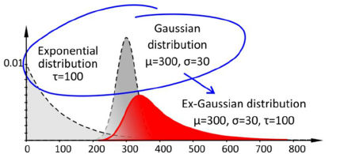

## Ex-Gaussian

[figure not shown]

## Ex-Gaussian

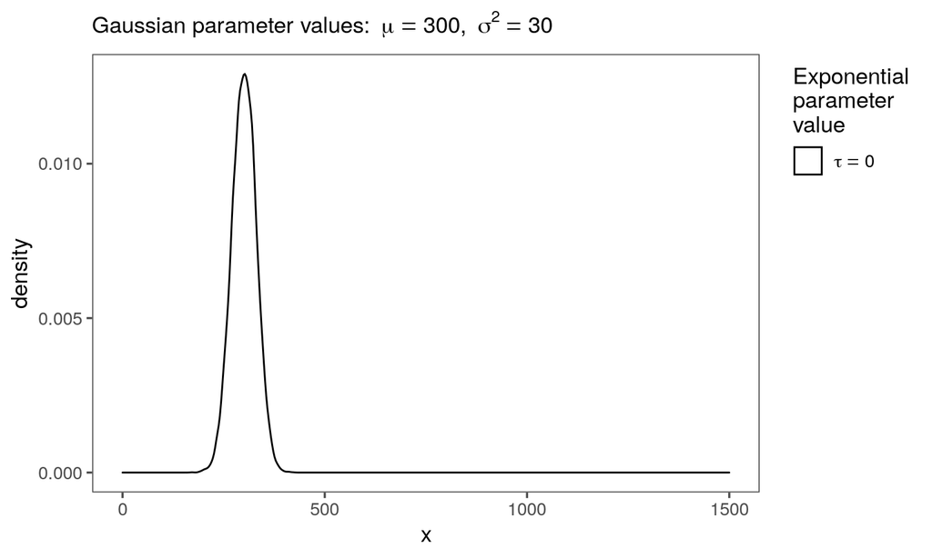

## Ex-Gaussian

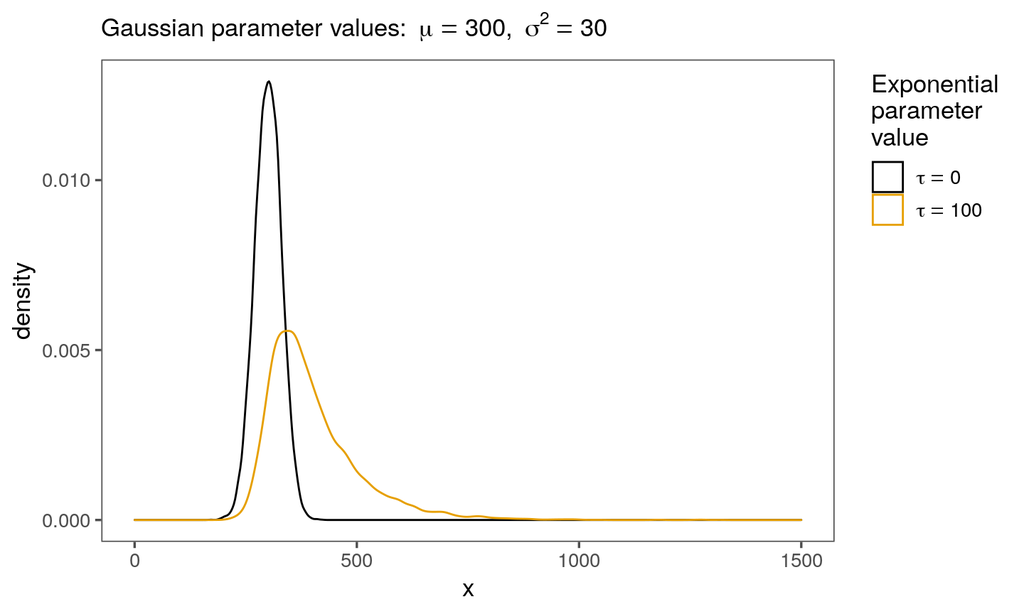

## Ex-Gaussian

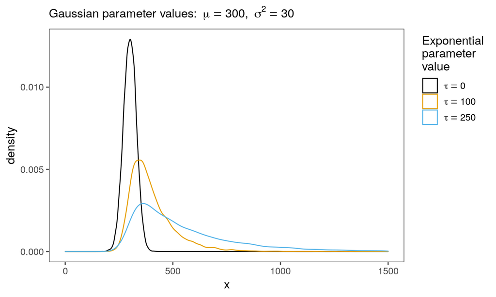

## Ex-Gaussian

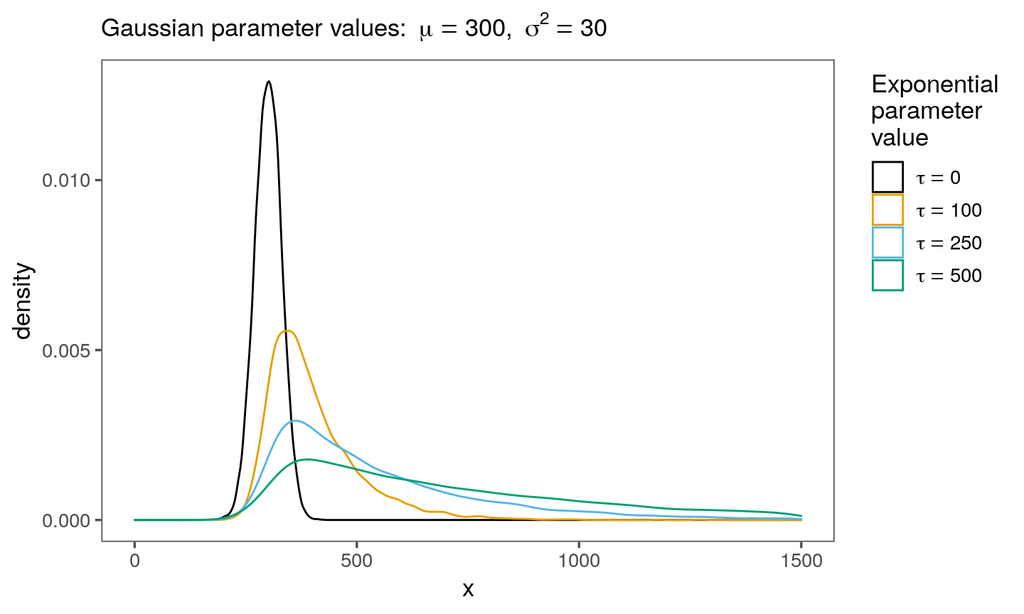

## Ex-Gaussian

```r
model <- bf(IKI ~ 1 + (1 | SubNo),
            beta ~ 1 + (1 | SubNo), # decay parameter (exponential component)
            family = exgaussian())

prior <- set_prior("normal(250, 20)", class = "Intercept") +
         set_prior("normal(6, 2)", class = "Intercept", dpar = "beta") # decay rate in log msecs
```

## Skew-Normal

- Non-symmetric Gaussian with extra skew-parameter \(\alpha\):
- positive skew \(\alpha > 0\)
- negative skew \(\alpha < 0\);

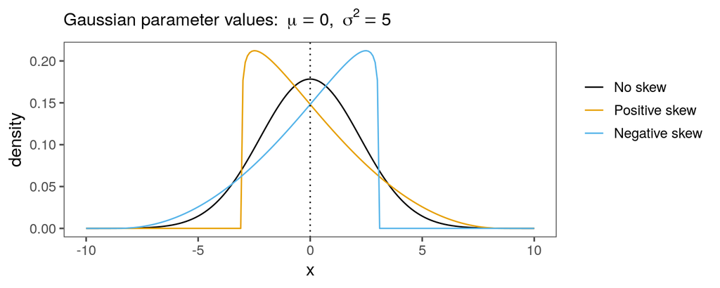

## Mixture model

\[ y \sim (1-\theta) \cdot N(\mu_1, \sigma^2_1) + \theta \cdot N(\mu_2, \sigma^2_2) \]

- Finite mixture model with two distributions (mixture components)
- Keystroke intervals come from a mix of two independent processes (Roeser et al., 2021):
- Short keystroke intervals: normal execution
- Long keystroke intervals: cognitively demanding
- Parameters:
  - \(\mu_1, \sigma^2_1\): mean and sd of one distribution
  - \(\mu_2, \sigma^2_2\): mean and sd of other distribution
  - \(\theta\): mixing proportion of distributions
- Mixing proportion \(\theta\) is probability of data coming from the second distribution.

## Mixture model

[figure not shown]

## Mixture model

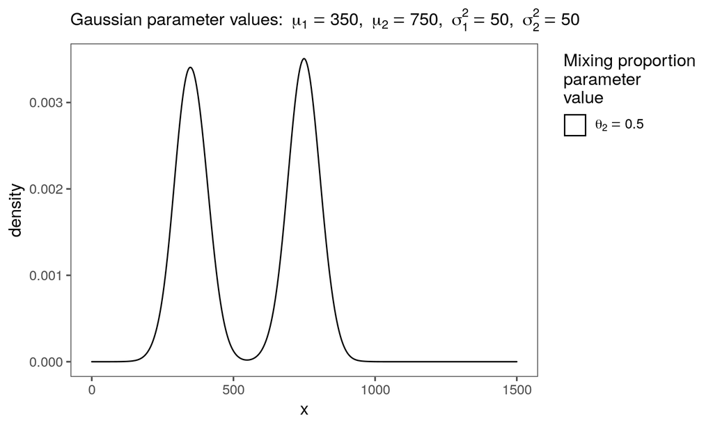

## Mixture model

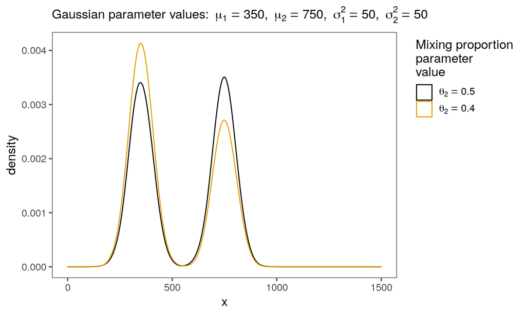

## Mixture model

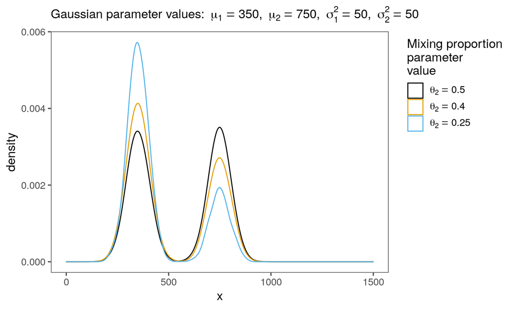

## Mixture model

```r
# Specify mixture model
mixture_of_lognormals <- mixture(lognormal(), lognormal())

# Specify model
model <- bf(IKI ~ 1 + (1 | SubNo),
            theta2 ~ 1 + (1 | SubNo),
            family = mixture_of_lognormals)

# Setup priors
prior <-  set_prior("normal(4, 1)", class = "Intercept", dpar = "mu1") +
          set_prior("normal(6, 1)", class = "Intercept", dpar = "mu2") +
          set_prior("beta(2, 2)", class = "Intercept", dpar = "theta2")
```

## Difference between models

| Model | Extreme values |
| --- | --- |
| Gaussian | Equally likely in both tails |
| log-Normal | Re-scale distance between adjacent values |
| skew-Normal | Extreme values are more likely in one tail |
| ex-Gaussian | Exponential component for right tail |
| Mixture model | Another distribution with mixing parameter |

## Model comparisons

### chapter 11 in Gelman et al. (2020); chapter 6 in McElreath (2016)

## Exercise: model comparison (1)

- What is a good model for keystroke intervals between sentences?
- How well does the model predict the data?
- Draw simulations from each model and compare them to the actual data.
- Complete `visualise_model_fit.R`.
- The script assumes that you have stored the posterior of homework models.

## Model predictions

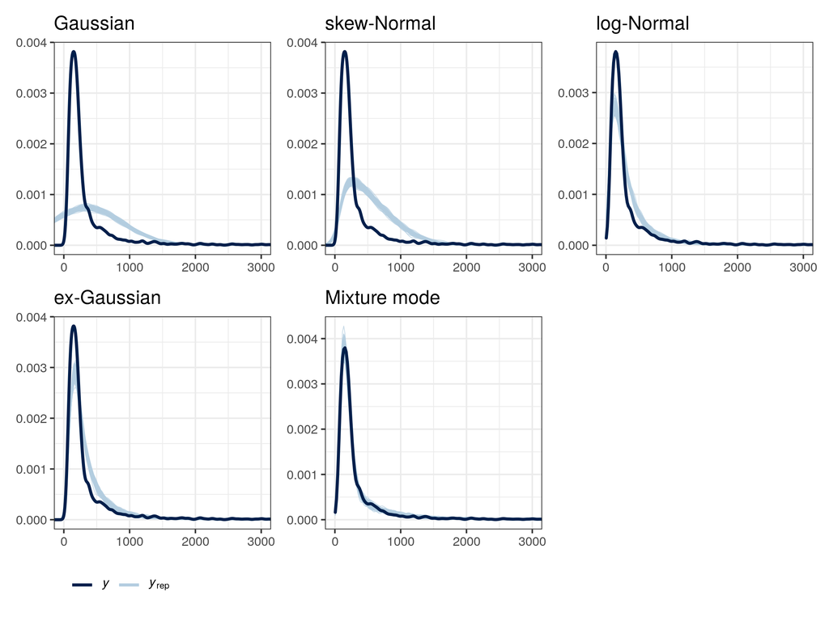

- Observed data \(y\) compared to 100 simulations per model \(y_{rep}\).
- Which model does the worst job; which does the best?
- But how well do models perform beyond the sample they were fitted on?

## Overfitting

- Complex models explain more variance but may make over optimistic predictions (Gelman et al., 2020).
- Example: brain size and body mass for seven primate species (from McElreath, 2016).

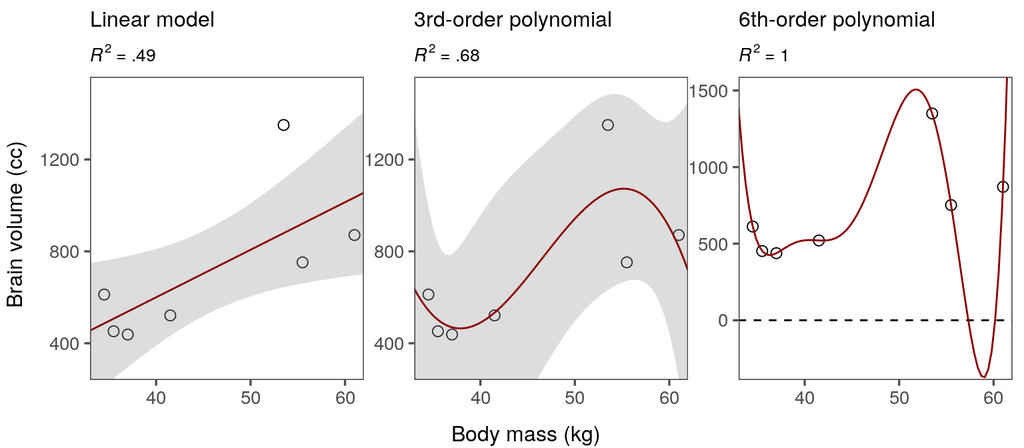

## Leave-One-Out (LOO) cross validation

- Cross validation bypasses the overfitting problem.
- Test how well the model predicts data *out-of-sample*.
- LOO: model on \(N-1\) data can predict the remaining data point.
- `loo()` uses a probability calculation to approximate LOO information criterion (i.e. Pareto smoothed importance sampling) (Vehtari et al., 2015, 2017).
- Adding up prediction results gives **expected log-predictive density** (\(elpd\)).
- Ability of the model to predict new data (i.e. predictive performance).

## Leave-One-Out (LOO) cross validation

```r
loo(gaussian)
```

```
Computed from 9000 by 2230 log-likelihood matrix

         Estimate    SE
elpd_loo -17044.3 123.4
p_loo        54.3   7.5
looic     34088.6 246.8
------
Monte Carlo SE of elpd_loo is 0.1.

Pareto k diagnostic values:
                         Count Pct.    Min. n_eff
(-Inf, 0.5]   (good)     2227  99.9%   497
 (0.5, 0.7]   (ok)          3   0.1%   344
   (0.7, 1]   (bad)         0   0.0%   <NA>
   (1, Inf)   (very bad)    0   0.0%   <NA>

All Pareto k estimates are ok (k < 0.7).
See help('pareto-k-diagnostic') for details.
```

- Approximation involved in `loo()` uses the log posterior predictive densities: likelihood of each data point given the distribution parameter estimates.
- These values don’t have an interpretation on their own but need to be considered in comparison to other models.

## Leave-One-Out (LOO) cross validation

```r
loo(gaussian)
```

```
Computed from 9000 by 2230 log-likelihood matrix

         Estimate    SE
elpd_loo -17044.3 123.4
p_loo        54.3   7.5
looic     34088.6 246.8
------
Monte Carlo SE of elpd_loo is 0.1.

Pareto k diagnostic values:
                         Count Pct.    Min. n_eff
(-Inf, 0.5]   (good)     2227  99.9%   497
 (0.5, 0.7]   (ok)          3   0.1%   344
   (0.7, 1]   (bad)         0   0.0%   <NA>
   (1, Inf)   (very bad)    0   0.0%   <NA>

All Pareto k estimates are ok (k < 0.7).
See help('pareto-k-diagnostic') for details.
```

## Exercise: model comparison (2)

- Script `model_comparison.R`
- Which model has the highest elpd score (i.e. highest predictive performance)?
- This script, again, assumes that you have stored the posterior of the 5 homework models.

## Model comparison

| model | elpd_diff | se_diff | elpd_loo | se_elpd_loo |
| --- | --- | --- | --- | --- |
| mixturemodel | 0.0 | 0.0 | -13773.6 | 80.7 |
| exgaussian | -626.3 | 56.3 | -14399.9 | 104.1 |
| lognormal | -736.8 | 38.6 | -14510.4 | 81.5 |
| skewnormal | -2125.2 | 95.2 | -15898.8 | 117.2 |
| gaussian | -3270.7 | 104.4 | -17044.3 | 123.4 |

<sup>a</sup> `elpd_loo` is reported as \(\widehat{elpd}\) and the difference as \(\Delta\widehat{elpd}\).

## Mixture-model evaluation

### see Roeser et al. (2021)

## Mixture-model parameters (population level)

```r
posterior_summary(mixturemodel, pars = "b_theta2_Intercept")[,-2] %>% round(2)
```

```
Estimate     Q2.5    Q97.5
    0.12     0.02     0.33
```

```r
coefs <- c("b_mu1_Intercept", "b_mu2_Intercept")
posterior_summary(mixturemodel, pars = coefs)[,-2] %>% exp() %>% round()
```

```
                Estimate Q2.5 Q97.5
b_mu1_Intercept      158  138   179
b_mu2_Intercept      471  400   558
```

```r
posterior_summary(mixturemodel, pars = c("sigma1", "sigma2"), fixed = T)[,-2] %>% round(2)
```

```
       Estimate Q2.5 Q97.5
sigma1     0.22 0.21  0.24
sigma2     0.80 0.75  0.85
```

## Mixture-model parameters (ppt level)

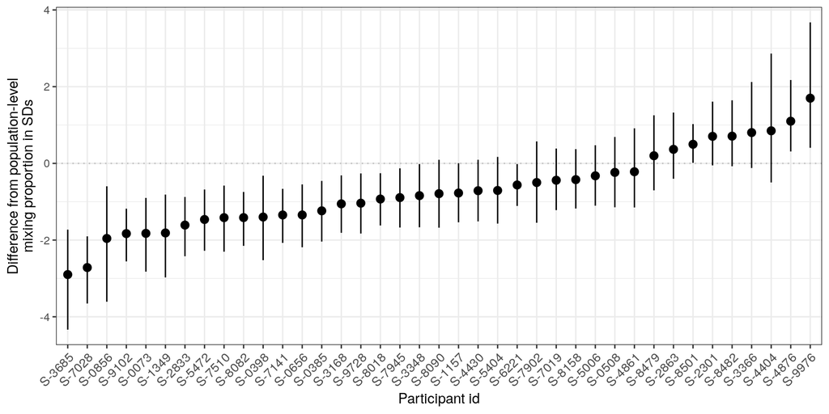

## Mixture-model evaluation

- Summarise the parameter estimates of the mixture model.
- Complete the `---`s in `mixturemodel_posterior.R` and run the script.
- Try to make sense of the parameter estimates.

## The end

## Summary

- A basic `brms` isn’t more complicated than `lmer`.
- Priors require some thinking.
- Bayesian models allow straight forward interpretation of parameter values without an arbitrary threshold for significance.
- `brms` allows us to fit various models of keystroke intervals.
- Mixture models showed better fit for sentence transitions.

## Recommended reading

- Bürkner’s tutorials (Bürkner, 2017, 2018, 2019; Bürkner & Vuorre, 2019)
- Vasishth’s tutorials (Nicenboim & Vasishth, 2016; Sorensen et al., 2016; Vasishth & Nicenboim, 2016)
- Book-length intros: Gelman et al. (2020), McElreath (2016), Kruschke (2014), Lambert (2018), Lee & Wagenmakers (2014)

## References

Baayen, R. H. (2008). *Analyzing linguistic data. A practical introduction to statistics using R*. Cambridge University Press.

Bürkner, P.-C. (2017). brms: An R package for Bayesian multilevel models using Stan. *Journal of Statistical Software*, *80*(1), 1–28. https://doi.org/10.18637/jss.v080.i01

Bürkner, P.-C. (2018). Advanced Bayesian multilevel modeling with the R package brms. *The R Journal*, *10*(1), 395–411. https://doi.org/10.32614/RJ-2018-017

Bürkner, P.-C. (2019). Bayesian item response modeling in R with brms and Stan. *arXiv Preprint arXiv:1905.09501*.

Bürkner, P.-C., & Vuorre, M. (2019). Ordinal regression models in psychology: A tutorial. *Advances in Methods and Practices in Psychological Science*, *2*(1), 77–101.

Chukharev-Hudilainen, E. (2014). Pauses in spontaneous written communication: A keystroke logging study. *Journal of Writing Research*, *6*(1), 61–84.

Gelman, A., Hill, J., & Vehtari, A. (2020). *Regression and other stories*. Cambridge University Press.

Gelman, A., & Rubin, D. B. (1992). Inference from iterative simulation using multiple sequences. *Statistical Science*, *7*(4), 457–472.

Kruschke, J. K. (2014). *Doing Bayesian data analysis: A tutorial with R, JAGS, and Stan*.

Lambert, B. (2018). *A student’s guide to Bayesian statistics*. Sage.

Lee, M. D., & Wagenmakers, E.-J. (2014). *Bayesian cognitive modeling: A practical course*. Cambridge University Press.

Matzke, D., & Wagenmakers, E.-J. (2009). Psychological interpretation of the ex- Gaussian and shifted Wald parameters: A diffusion model analysis. *Psychonomic Bulletin & Review*, *16*(5), 798–817.

McElreath, R. (2016). *Statistical rethinking: A Bayesian course with examples in R and Stan*. CRC Press.

Nicenboim, B., & Vasishth, S. (2016). Statistical methods for linguistic research: Foundational Ideas – Part II. *Language and Linguistics Compass*, *10*(11), 591–613.

Roeser, J., De Maeyer, S., Leijten, M., & Van Waes, L. (2021). *Modelling typing disfluencies using bayesian mixture models*. https://osf.io/y3p4d/

Rouder, J. N., Morey, R. D., & Wagenmakers, E.-J. (2016). The interplay between subjectivity, statistical practice, and psychological science. *Collabra*, *2*(1), 1–12.

Sorensen, T., Hohenstein, S., & Vasishth, S. (2016). Bayesian linear mixed models using Stan: A tutorial for psychologists, linguists, and cognitive scientists. *Quantitative Methods for Psychology*, *12*(3), 175–200.

Vasishth, S., & Nicenboim, B. (2016). Statistical methods for linguistic research: Foundational ideas – Part I. *arXiv Preprint arXiv:1601.01126*.

Vehtari, A., Gelman, A., & Gabry, J. (2015). Pareto smoothed importance sampling. *arXiv Preprint arXiv:1507.02646*.

Vehtari, A., Gelman, A., & Gabry, J. (2017). Practical bayesian model evaluation using leave-one-out cross-validation and WAIC. *Statistics and Computing*, *27*(5), 1413–1432.